# IS 605 Assignment 11

David Stern

April 22, 2015

## Problem 1

Based on a sample of 15 data points, we will perform a regression analysis that will show how maximum heart rate is related to age. The equation we are evaluating is

$MaxHR = 220 - Age$

```r
Age <- c(18,23,25,35,65,54,34,56,72,19,23,42,18,39,37)
MaxHR <- c(202,186,187,180,156,169,174,172,153,199,193,174,198,183,178)
```

This will show us the intercept and slope of the least regression line. It appears that the equation is almost spot-on.The y-intercept is 210 and the slope is -0.7977, a very strong negative correlation. To be more precise:

The null hypothesis is that Age does not have an effect on HR $B_{1}$ = 0. The alternative hypothesis is that Heart Rate decreases with Age: $B_{0}$ < 0

```r
fit <- lm(MaxHR ~ Age)
fit
```

```
##
## Call:
## lm(formula = MaxHR ~ Age)
##
## Coefficients:
## (Intercept)          Age
##    210.0485      -0.7977
```

Draw up a quick scatterplot:

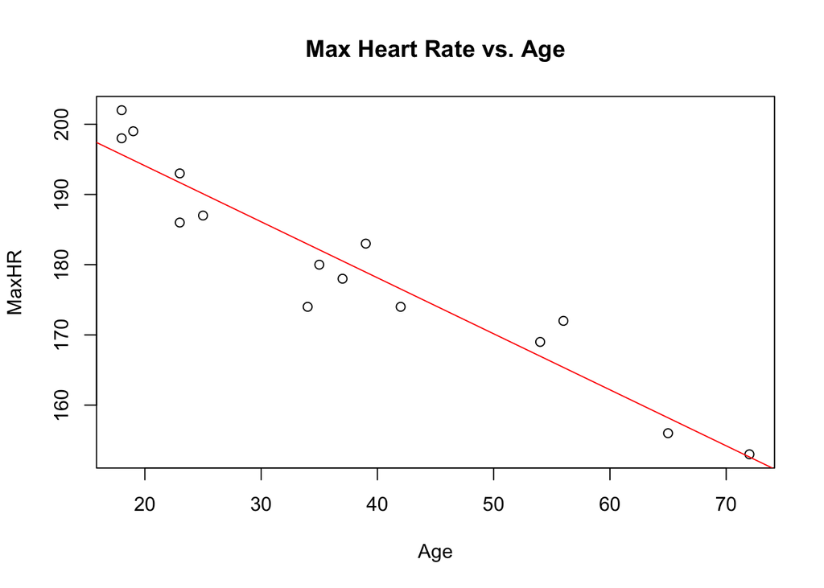

```r
plot(Age,MaxHR,main="Max Heart Rate vs. Age") # Appears to be a strong negative correlations
abline(fit,col="red")
```

We can determine the significance of the relationship between max heart rate and age by calling the summary stats for the least regression line and checking the p-value:

```r
summary(fit)
```

```
##
## Call:
## lm(formula = MaxHR ~ Age)
##
## Residuals:
##     Min      1Q  Median      3Q     Max
## -8.9258 -2.5383  0.3879  3.1867  6.6242
##
## Coefficients:
##              Estimate Std. Error t value Pr(>|t|)
## (Intercept) 210.04846    2.86694   73.27  < 2e-16 ***
## Age          -0.79773    0.06996  -11.40 3.85e-08 ***
## ---
## Signif. codes:  0 '***' 0.001 '**' 0.01 '*' 0.05 '.' 0.1 ' ' 1
##
## Residual standard error: 4.578 on 13 degrees of freedom
## Multiple R-squared:  0.9091, Adjusted R-squared:  0.9021
## F-statistic:   130 on 1 and 13 DF,  p-value: 3.848e-08
```

Since the p-value is far smaller than the 0.05, we can determine that there is a very significant relationship between the two variables. We can safely reject the null hypothesis.

## Problem 2

```r
setwd("/Users/davidstern/Documents")
carData <- read.table("auto-mpg.data",header=F)
colnames(carData) <- c("displacement", "horsepower", "weight", "acceleration", "mpg")
```

$\textbf{Displacement}$

```r
fitDisp <- lm(carData$displacement ~ carData$mpg)
fitDisp
```

```
##
## Call:
## lm(formula = carData$displacement ~ carData$mpg)
##
## Coefficients:
## (Intercept)  carData$mpg
##      447.50       -10.79
```

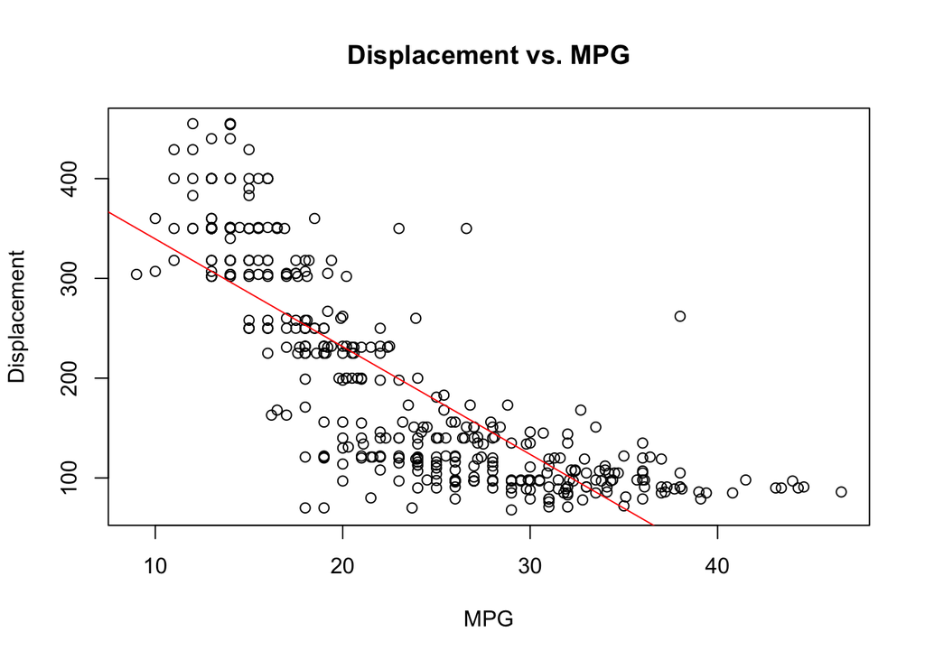

```r
plot(carData$mpg,carData$displacement,main="Displacement vs. MPG",xlab="MPG",ylab="Displacement")
abline(fitDisp,col="red")
```

The Displacement Equation is:

$Displacement = 447.50 - 10.79 \times MPG$

$\textbf{Horsepower}$

```r
fitHP <- lm(carData$horsepower ~ carData$mpg)
fitHP
```

```
##
## Call:
## lm(formula = carData$horsepower ~ carData$mpg)
##
## Coefficients:
## (Intercept)  carData$mpg
##     194.476       -3.839
```

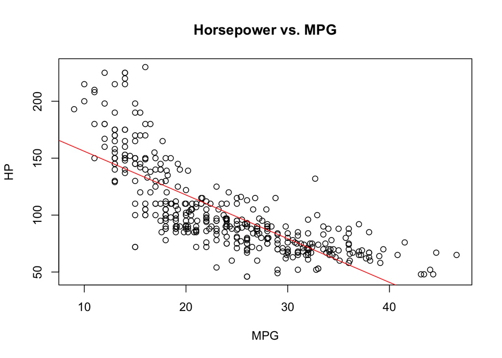

```r
plot(carData$mpg,carData$horsepower,main="Horsepower vs. MPG",xlab="MPG",ylab="HP")
abline(fitHP,col="red")
```

The horsepower equation is:

$HP = 194.48 - 3.84 \times MPG$

$\textbf{Weight}$

```r
fitWeight <- lm(carData$weight ~ carData$mpg)
fitWeight
```

```
##
## Call:
## lm(formula = carData$weight ~ carData$mpg)
##
## Coefficients:
## (Intercept)  carData$mpg
##     5101.11       -90.57
```

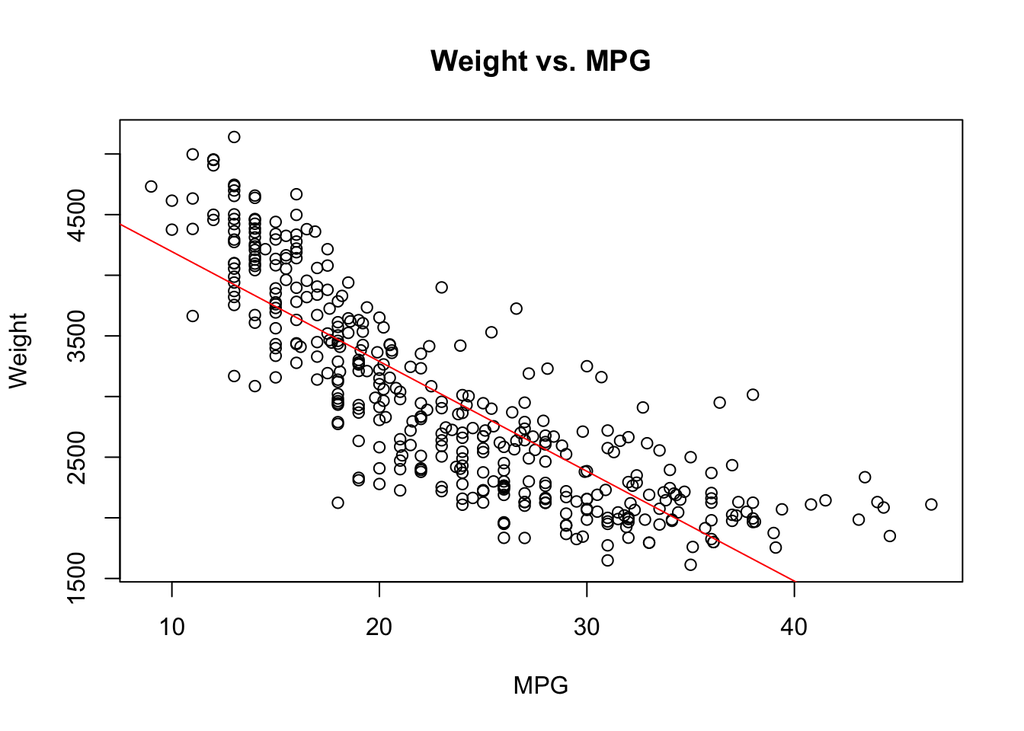

```r
plot(carData$mpg,carData$weight,main="Weight vs. MPG",xlab="MPG",ylab="Weight")
abline(fitWeight,col="red")
```

The weight equation is $Weight = 5101.11 - 90.57 \times MPG$

$\textbf{Acceleration}$

```r
fitAcceleration <- lm(carData$acceleration ~ carData$mpg)
fitAcceleration
```

```
##
## Call:
## lm(formula = carData$acceleration ~ carData$mpg)
##
## Coefficients:
## (Intercept)  carData$mpg
##     12.0330       0.1496
```

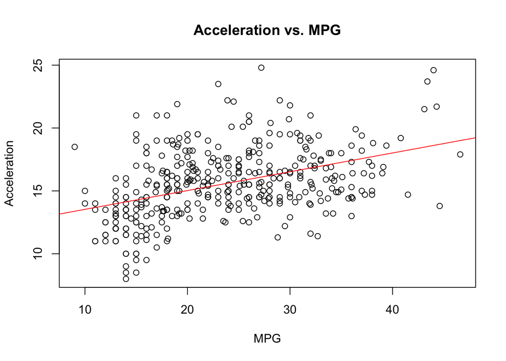

```r
plot(carData$mpg,carData$acceleration,main="Acceleration vs. MPG",xlab="MPG",ylab="Acceleration")
abline(fitAcceleration,col="red")
```

The Acceleration Equation is:

$Acceleration = 12.03 + 0.15 \times MPG$

Now we will will find the linear regression fit equation considering mpg as a dependent variable and the displacement,horsepower, weight, and acceleration as independent variables.

First we will perform the regression by taking 40 random data points from the mpg dataset:

```r
set.seed(23382)
set40 <- carData[sample(1:392,40),]
fit40 <- lm(mpg ~ displacement +  horsepower + weight + acceleration,data = set40)
fit40
```

```
##
## Call:
## lm(formula = mpg ~ displacement + horsepower + weight + acceleration,
##     data = set40)
##
## Coefficients:
##  (Intercept)  displacement    horsepower        weight  acceleration
##    48.779259      0.006894     -0.052741     -0.005744     -0.331730
```

```r
summary(fit40)
```

```
##
## Call:
## lm(formula = mpg ~ displacement + horsepower + weight + acceleration,
##     data = set40)
##
## Residuals:
##     Min      1Q  Median      3Q     Max
## -5.8249 -2.0186 -0.4044  1.7243  8.9020
##
## Coefficients:
##               Estimate Std. Error t value Pr(>|t|)
## (Intercept)  48.779259   5.508439   8.855 1.85e-10 ***
## displacement  0.006894   0.017182   0.401   0.6907
## horsepower   -0.052741   0.039971  -1.319   0.1956
## weight       -0.005744   0.002412  -2.382   0.0228 *
## acceleration -0.331730   0.324157  -1.023   0.3132
## ---
## Signif. codes:  0 '***' 0.001 '**' 0.01 '*' 0.05 '.' 0.1 ' ' 1
##
## Residual standard error: 3.277 on 35 degrees of freedom
## Multiple R-squared:  0.7792, Adjusted R-squared:  0.7539
## F-statistic: 30.87 on 4 and 35 DF,  p-value: 4.857e-11
```

The standard errors for each of the variables are as follows:

Displacement: 0.017182, Horsepower: 0.039971, Weight: 0.002412, Acceleration: 0.324157

```r
confint(fit40,level=0.95)
```

```
##                    2.5 %        97.5 %
## (Intercept)  37.59653259 59.9619854460
## displacement -0.02798717  0.0417751869
## horsepower   -0.13388675  0.0284041973
## weight       -0.01063966 -0.0008483064
## acceleration -0.98980368  0.3263446190
```

We will now perform the multiple regression using all 392 data points.

```r
all <- lm(mpg ~ displacement +  horsepower + weight + acceleration,data = carData)
all
```

```
##
## Call:
## lm(formula = mpg ~ displacement + horsepower + weight + acceleration,
##     data = carData)
##
## Coefficients:
##  (Intercept)  displacement    horsepower        weight  acceleration
##    45.251140     -0.006001     -0.043608     -0.005281     -0.023148
```

Our equation is:

$mpg = 45.251140 - 0.006001 \times displacement - 0.043608 \times horsepower - 0.005281 \times weight - 0.023148 \times acceleration$

```r
summary(all)
```

```
##
## Call:
## lm(formula = mpg ~ displacement + horsepower + weight + acceleration,
##     data = carData)
##
## Residuals:
##     Min      1Q  Median      3Q     Max
## -11.378  -2.793  -0.333   2.193  16.256
##
## Coefficients:
##                Estimate Std. Error t value Pr(>|t|)
## (Intercept)  45.2511397  2.4560447  18.424  < 2e-16 ***
## displacement -0.0060009  0.0067093  -0.894  0.37166
## horsepower   -0.0436077  0.0165735  -2.631  0.00885 **
## weight       -0.0052805  0.0008109  -6.512  2.3e-10 ***
## acceleration -0.0231480  0.1256012  -0.184  0.85388
## ---
## Signif. codes:  0 '***' 0.001 '**' 0.01 '*' 0.05 '.' 0.1 ' ' 1
##
## Residual standard error: 4.247 on 387 degrees of freedom
## Multiple R-squared:  0.707,  Adjusted R-squared:  0.704
## F-statistic: 233.4 on 4 and 387 DF,  p-value: < 2.2e-16
```

The standard errors for each of the variables are as follows:

Displacement: 0.0067093, Horsepower: 0.0165735, Weight: 0.0008109, Acceleration: 0.1256012

The 95% confidence interval for the entire data set is as follows:

```r
confint(all,level=0.95)
```

```
##                     2.5 %       97.5 %
## (Intercept)  40.422278855 50.080000544
## displacement -0.019192122  0.007190380
## horsepower   -0.076193029 -0.011022433
## weight       -0.006874738 -0.003686277
## acceleration -0.270094049  0.223798050
```

As we can see from the two results, the standard error and significance vary greatly between the sample and the entire population. Based on these significant levels for the population, it seems that horsepower and weight have the most significant impact on mpg.